# Modelling

## Data Prep (Yes, there’s more…)

First we need to make sure we have the data from the summary stuff. Below we load in the oviposition data at Broad habitat levels 1 and 2, as well as the phylogenetic tree we made prior.

```r
library(tidyverse)
library(tidybayes)
library(ape)
library(brms)
# Habitat level 1, the broadest classification
ovipos_hab1 <- read_csv("Oviposition_Summary_Hab1.csv")
# Habitat level 2, a less broad type
ovipos_hab2 <- read_csv("Oviposition_Summary_Hab2.csv")
# A Tree with all the species we need in it
tree <- read.tree("final_tree.new")
```

Quickly we will put a `_` inbetween the genus and species of our mosquito names because they don’t play well with gaps in their names using the phylogenetic tree data.

```r
# Replcae " " with "_" in msoquito_species and give us it back
ovipos_hab1 <- ovipos_hab1 %>% mutate(mosquito_species = str_replace(mosquito_species, " ", "_"))
ovipos_hab2 <- ovipos_hab2 %>% mutate(mosquito_species = str_replace(mosquito_species, " ", "_"))
```

Now we need to make sure we have the right species in our tree, so the same ones in our dataframe, and make a distance matrix or covariance-variance matrix. A nice function in the `caper` package will do all this for us and put it in a nice list where can then call objects from.

```r
library(caper)
# This is to remove a duplicated tip label in the tree - my fault when assembling
which(duplicated(tree$tip.label))
```

```
## [1] 12
```

```r
# We can rename it and it will be removed in the next step
tree$tip.label[12] <- "DuplicatedSpp"

# This is a nice function to generate an object with all the same tips, phylo, VCV, and data for a cetrain tree.
hab1 <- comparative.data(phy = tree, data = as.data.frame(ovipos_hab1), names.col = mosquito_species, vcv = TRUE)

# This is the structure
hab1
```

```
## Comparative dataset of 20 taxa:
## Phylogeny: tree
##    20 tips, 19 internal nodes
##    chr [1:20] "Aedes_aegypti" "Aedes_albopictus" "Aedes_vexans" ...
## VCV matrix present:
##    'VCV.array' num [1:20, 1:20] 7.31 7.23 7.22 7.19 7.19 ...
## Data: as.data.frame(ovipos_hab1)
##    $ permanent                       : num [1:20] 1 1 1 1 0 1 0 1 1 1 ...
##    $ transitory                      : num [1:20] 1 1 1 1 1 1 1 1 1 1 ...
##    $ artificial                      : num [1:20] 1 1 1 1 0 0 1 1 1 1 ...
##    $ natural                         : num [1:20] 1 1 1 1 1 1 1 1 1 1 ...
##    $ hab_1_e                         : num [1:20] 1 1 1 0 0 0 0 1 0 1 ...
##    $ hab_1_f                         : num [1:20] 1 0 1 0 0 0 0 1 1 1 ...
##    $ hab_1_g                         : num [1:20] 1 0 1 1 0 0 0 1 1 1 ...
##    $ hab_1_j                         : num [1:20] 1 1 1 1 0 0 1 1 1 1 ...
```

[output cut: 28 more lines]

## Phylogenetic Logistic Regression

I can’t get any of the phylogenetic models to run, ape::binaryPGLMM, phylolm:phyloglm or pez::communityPGLMM. So isntead have done what I can to get this all to work in BRMS, and to my surprise, it works quite well and sampling is good.

For BRMS to work with phylogeny models using stan we need a variance-covariance matrix (vcv) from our phylogeny. This is easily done with `ape::vcv.phylo()`.

We also need the data to have the mosquito species as a actual variable and not rownames, and a formula explaining the structure of what we want to predict to transfer to stan code.

```r
# This gets us our VCV
A <- ape::vcv.phylo(hab1$phy)

# this gets us our dataframe with the mosquitoes in the data and not as a rowname
data <- hab1$data %>% rownames_to_column(var = "mosquito_species")

# Formula design  for just habitat predictors:
habs <- data %>% dplyr::select(hab_1_e:hab_1_a) %>% colnames()

# The formula
habformula <-
  # vector is outcome var at the start
  paste("vector ~ ",
        # now paste all the habitat vars as interaction predictors with "+" in the middle
        paste(habs, collapse = " + "),
        # this deals with our phylogeny telling brms to look for this vcv
        # to apply to mosquito species in our dataframe as a random effect
        "+ (1 | gr(mosquito_species, cov = A))")
```

Overall the formula for this model looks like this:

```r
habformula
```

```
## [1] "vector ~  hab_1_e + hab_1_f + hab_1_g + hab_1_j + hab_1_x + hab_1_c + hab_1_d + hab_1_i + hab_1_h + hab_1_a + (1 | gr(mosquito_species, cov = A))"
```

Now lets compile the model using multiple cores, I’ve turned off the ouput because it can take a while and fill up the page with goop.

So instead here is out model output.

```r
model_simple
```

```
##  Family: bernoulli
##   Links: mu = logit
## Formula: vector ~ hab_1_e + hab_1_f + hab_1_g + hab_1_j + hab_1_x + hab_1_c + hab_1_d + hab_1_i + hab_1_h + hab_1_a + (1 | gr(mosquito_species, cov = A))
##    Data: data (Number of observations: 20)
## Samples: 4 chains, each with iter = 2000; warmup = 1000; thin = 1;
##          total post-warmup samples = 4000
##
## Group-Level Effects:
## ~mosquito_species (Number of levels: 20)
##               Estimate Est.Error l-95% CI u-95% CI Rhat Bulk_ESS Tail_ESS
## sd(Intercept)    60.15     46.03    19.70   163.50 1.00     2372     2679
##
## Population-Level Effects:
##           Estimate Est.Error l-95% CI u-95% CI Rhat Bulk_ESS Tail_ESS
## Intercept   -21.36     46.55  -111.98    71.74 1.00     3059     2888
## hab_1_e       6.21      8.27   -10.56    22.37 1.00     4185     3295
## hab_1_f       2.41      8.54   -14.05    19.47 1.00     4375     2792
## hab_1_g       3.91      8.70   -13.55    21.40 1.00     4237     3116
## hab_1_j       4.97      8.40   -11.43    21.85 1.00     4753     2819
## hab_1_x       1.63      8.37   -14.51    18.61 1.00     3810     3119
## hab_1_c      -0.95      8.26   -17.47    15.21 1.00     3613     2805
## hab_1_d      -1.00      8.26   -17.66    15.19 1.00     4168     3225
## hab_1_i      -0.83      8.85   -18.52    16.47 1.00     4764     2838
## hab_1_h       0.56      9.56   -17.83    19.49 1.00     5411     3073
## hab_1_a       3.94      9.44   -14.46    22.55 1.00     5146     3059
##
## Samples were drawn using sampling(NUTS). For each parameter, Bulk_ESS
## and Tail_ESS are effective sample size measures, and Rhat is the potential
## scale reduction factor on split chains (at convergence, Rhat = 1).
```

Below shows convergence information for the chains and estiamtes for the parameters of each covariate.

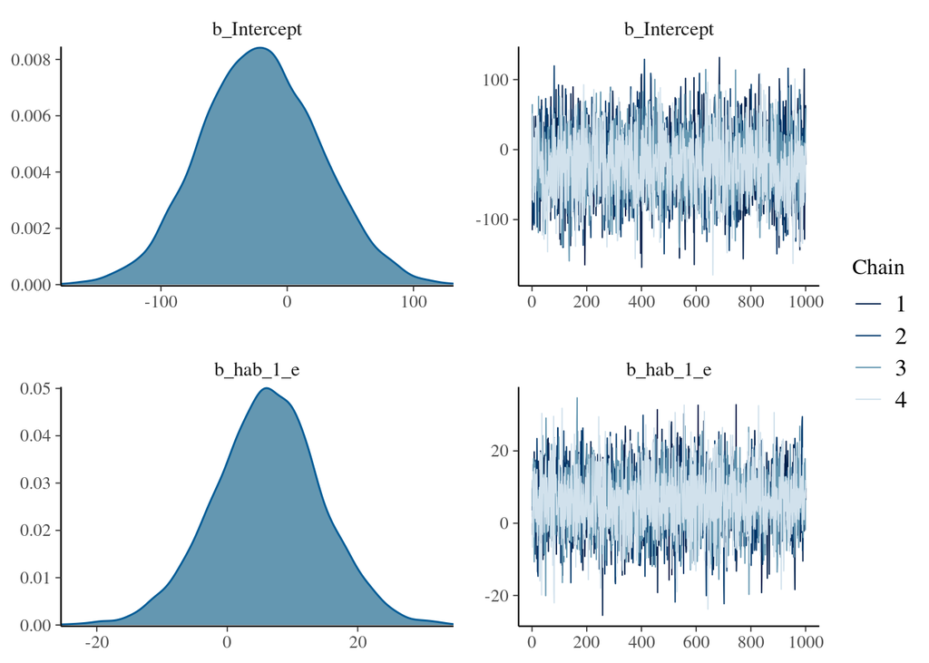

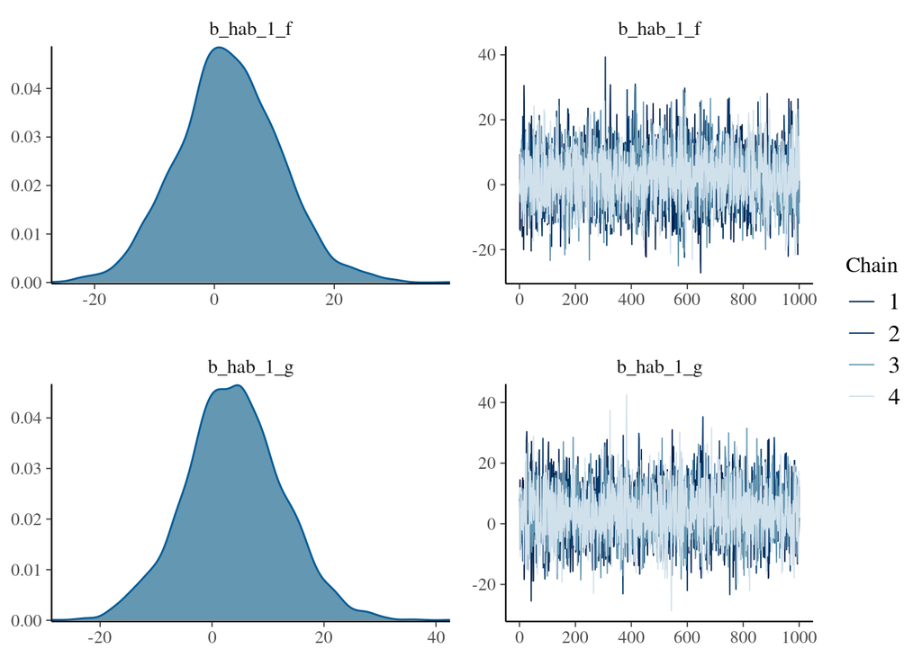

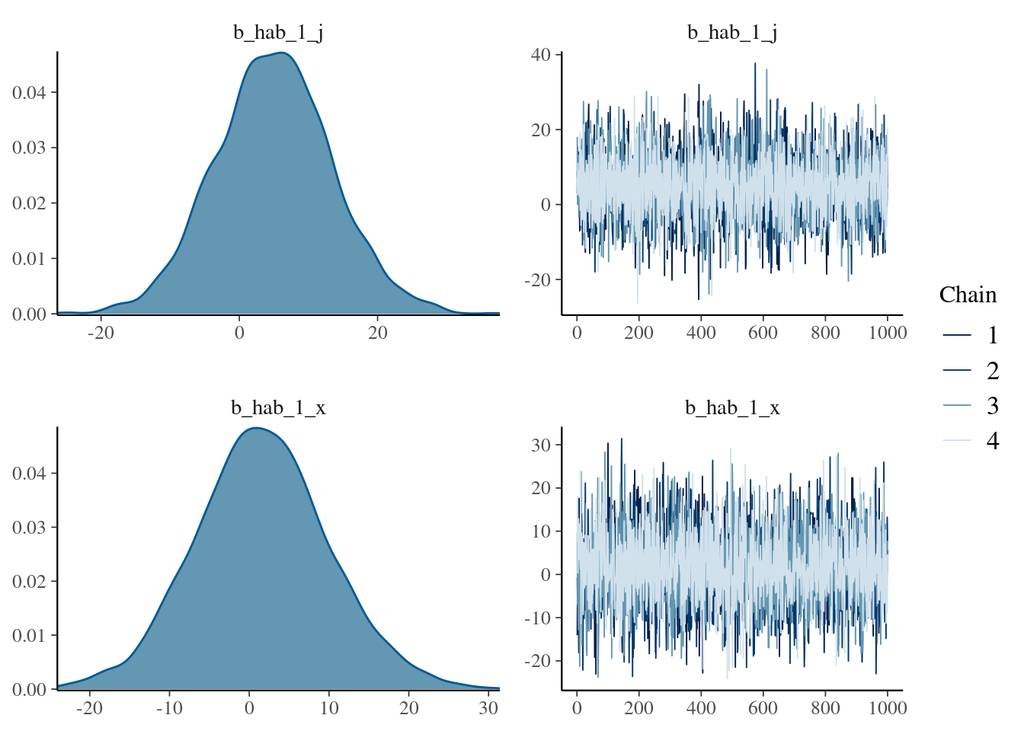

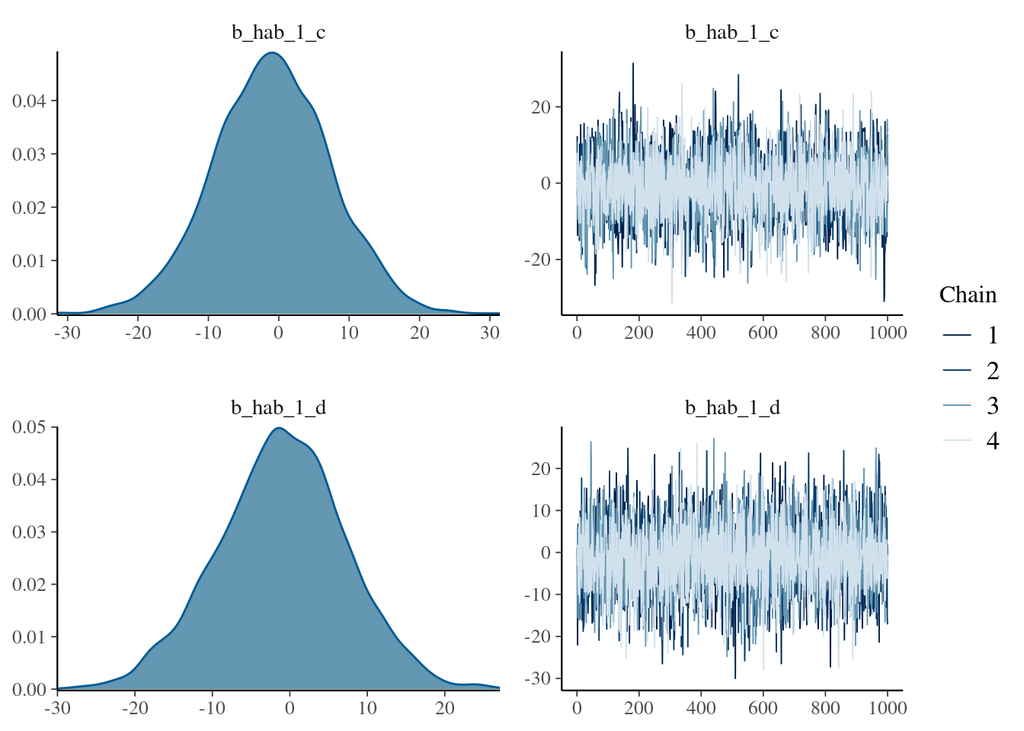

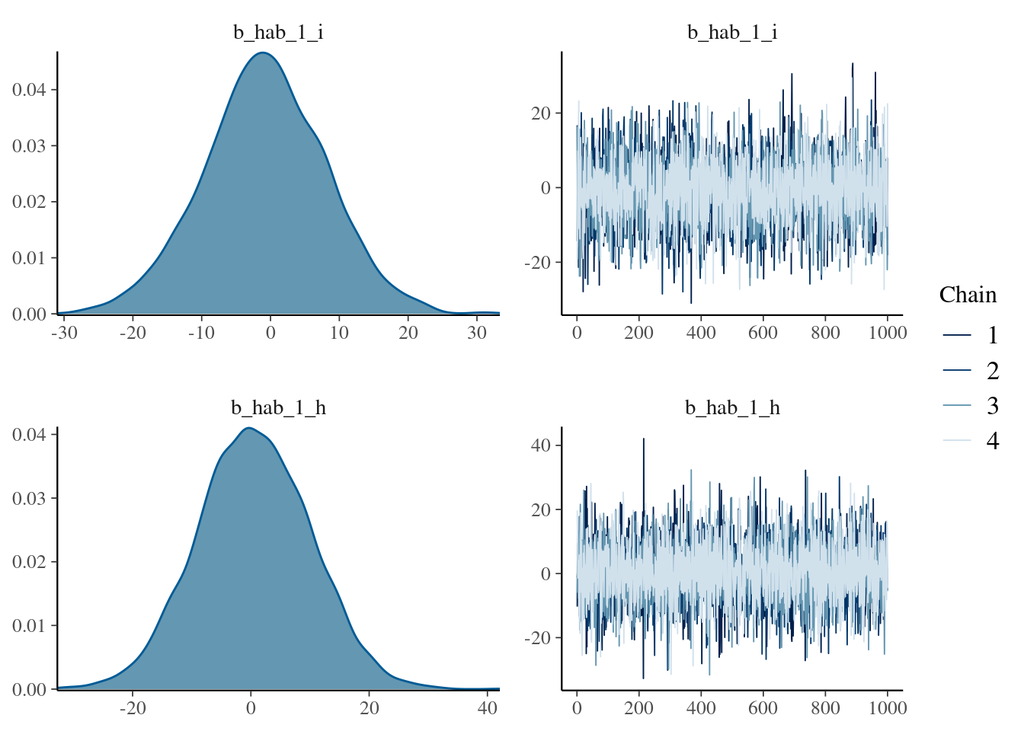

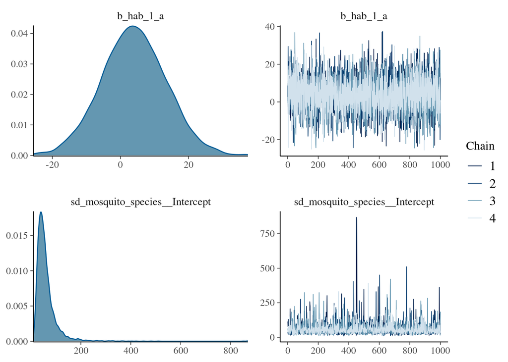

```r
plot(model_simple, N = 2, ask = FALSE)
```

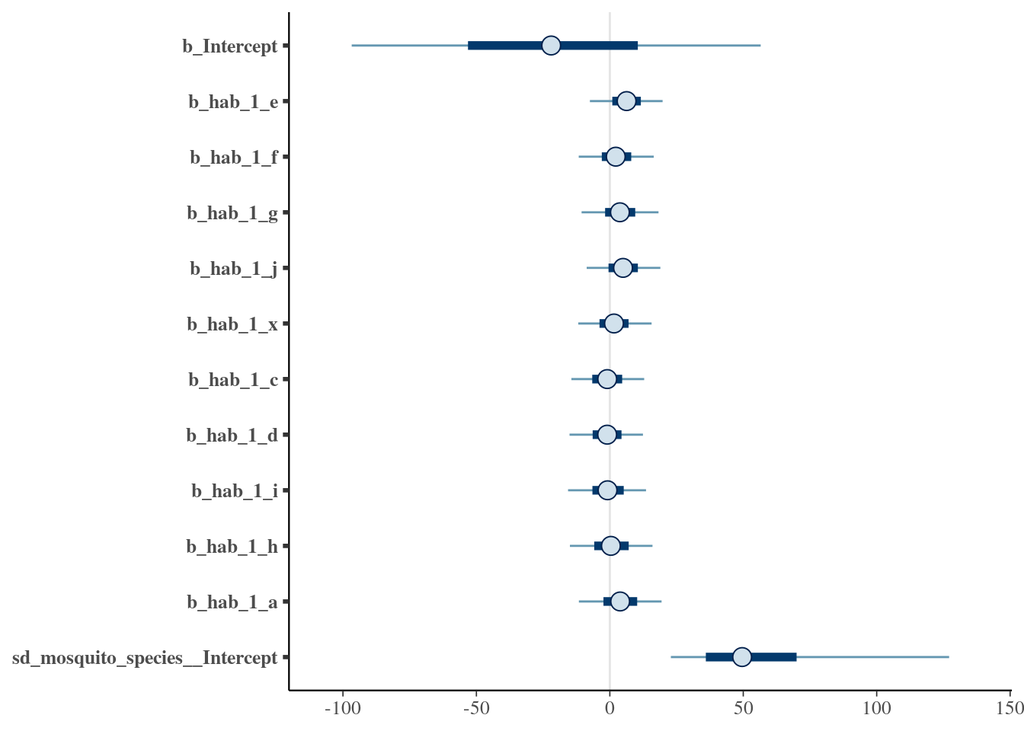

```r
mcmc_plot(model_simple)
```

The `ppcheck()` function runs a posterior predictive chek ont he model, estimating how well the model would fit to new data, basically the lines should be close and of similar shapes.

```r
# Full model
pp_check(model_simple)
```

```
## Using 10 posterior samples for ppc type 'dens_overlay' by default.
```

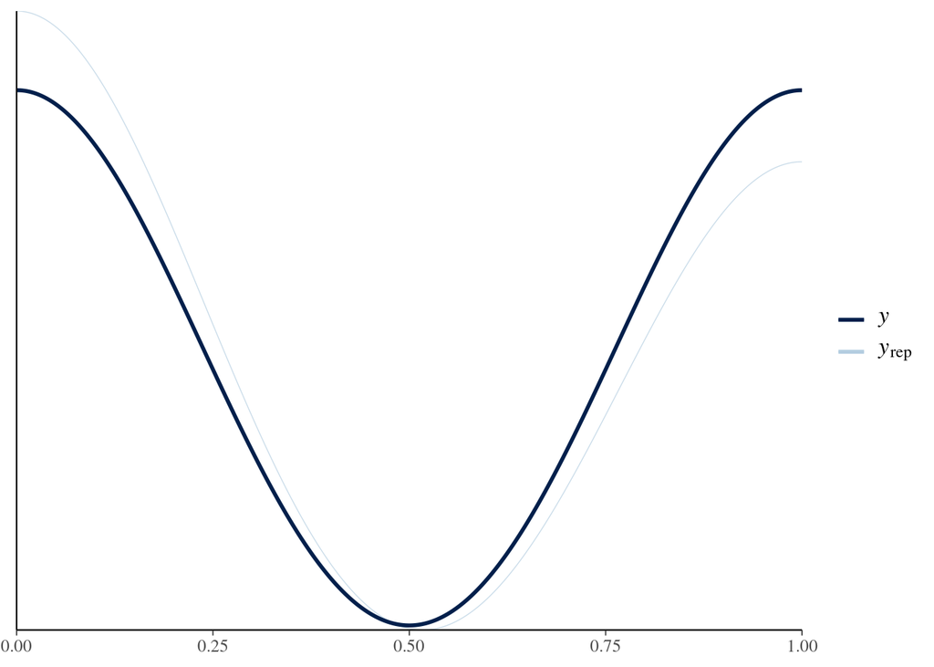

```r
# For a specific variable
pp_check(model_simple, resp = "hab_1_e") + ggtitle("ppcheck function for the response variable hab_1_e")
```

```
## Using 10 posterior samples for ppc type 'dens_overlay' by default.
```

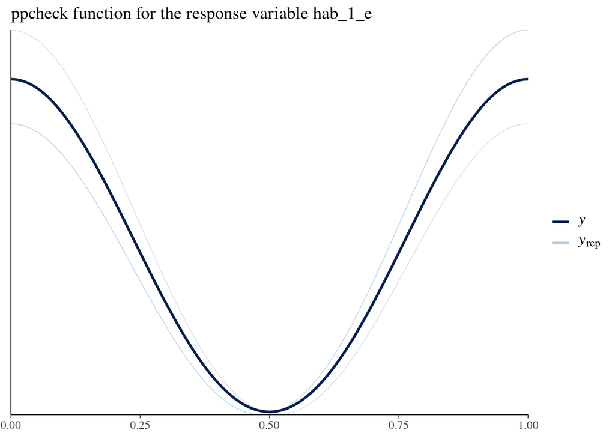

## No phylogeny?

What about an example where we don’t include the phylogenetic effects of the species?

```r
model_nophylo
```

```
##  Family: bernoulli
##   Links: mu = logit
## Formula: vector ~ hab_1_e + hab_1_f + hab_1_g + hab_1_j + hab_1_x + hab_1_c + hab_1_d + hab_1_i + hab_1_h + hab_1_a
##    Data: data (Number of observations: 20)
## Samples: 4 chains, each with iter = 2000; warmup = 1000; thin = 1;
##          total post-warmup samples = 4000
##
## Population-Level Effects:
##           Estimate Est.Error l-95% CI u-95% CI Rhat Bulk_ESS Tail_ESS
## Intercept    -6.62      3.90   -15.11     0.12 1.00     1734     2206
## hab_1_e       7.75      3.48     1.72    15.24 1.00     1560     2057
## hab_1_f      -2.67      5.24   -12.54     8.34 1.00     1550     1856
## hab_1_g      -1.66      4.57   -11.43     6.40 1.00     1696     1668
## hab_1_j       6.69      3.79     0.32    14.98 1.00     1655     2144
## hab_1_x      -2.08      2.50    -7.11     2.68 1.00     2163     2695
## hab_1_c      -1.77      1.83    -5.57     1.55 1.00     2735     2431
## hab_1_d       2.21      2.09    -1.76     6.55 1.00     2170     2381
## hab_1_i       6.91      3.96    -0.03    15.63 1.00     1625     2138
## hab_1_h       3.34      8.05   -10.08    20.83 1.00     2077     2109
## hab_1_a      11.58      6.18     1.18    25.29 1.00     2176     2599
##
## Samples were drawn using sampling(NUTS). For each parameter, Bulk_ESS
## and Tail_ESS are effective sample size measures, and Rhat is the potential
## scale reduction factor on split chains (at convergence, Rhat = 1).
```

Just by looking at the lower 95% and upper 95% intervals we can see that not including the phylogenetic effect of the model makes some predictors more likely to determine a mosquito a vector or not. This must mean that the phylogenetic effect is important in the model we specified earlier, and biologically is probably more accurate too.

We can pull those out and see them more clearly using the `fixef()` function on our model, and then transforming the parameters back out of the logit link space that we used to fit the model using `inv_logit_scaled()`.

```r
fixef(model_nophylo) %>% inv_logit_scaled()
```

```
##              Estimate Est.Error         Q2.5     Q97.5
## Intercept 0.001335338 0.9801243 2.752481e-07 0.5294137
## hab_1_e   0.999570856 0.9700945 8.478869e-01 0.9999998
## hab_1_f   0.064978843 0.9947354 3.581232e-06 0.9997620
## hab_1_g   0.160148823 0.9897782 1.082297e-05 0.9983488
## hab_1_j   0.998757758 0.9779585 5.803834e-01 0.9999997
## hab_1_x   0.110625526 0.9239315 8.160094e-04 0.9358826
## hab_1_c   0.145753948 0.8623471 3.787809e-03 0.8250904
## hab_1_d   0.901012805 0.8895862 1.465837e-01 0.9985761
## hab_1_i   0.999005933 0.9813498 4.912911e-01 0.9999998
## hab_1_h   0.965845154 0.9996816 4.207472e-05 1.0000000
## hab_1_a   0.999990666 0.9979321 7.642298e-01 1.0000000
```

We should try and compare our models using some information criterion, you can use LOO or WAIC for bayesian models. Here we would expect the criterion for our non-phylo including model to be much simpler because there are far less parameters, but does it predict as well?

Using loo the model gets refit lots and lots of times leaving out covariates as it goes, this will take a long time but can be worth it. The result is a metric called ELPD. A negative ELPD_diff means the model predicts worse than the baseline model (0)

```r
model_simple <- add_criterion(model_simple, "loo")
model_nophylo <- add_criterion(model_nophylo, "loo")
loo_compare(model_simple, model_nophylo)
```

```
##               elpd_diff se_diff
## model_simple    0.0       0.0
## model_nophylo -22.9       5.4
```

So here, from our results we see that despite there being more parameters in the phylogenetic model, when we use it to predict it gets the right answer more often, and is therefore the better model. We should use the phylogenetic random effect in our models.

Lastly we should look at `launch_shinystan()` to see the model in more depth. From Shinystan you can actually download pdf/ggplot objects of the plots and tables that describe the model. This should make for quick inputting into your report Lucy, without the need for too much effort! You should find these in the estimate tab of Shinystan.